# Effects of Skewness on Sample Size in CLT

Author

Visruth Srimath Kandali. Beth Chance, California Polytechnic Department of Statistics

## Creating the Data

```julia
using Distributions, Random, DataFrames, CSV, StatsBase

function standardize(x̄, μ, σ, n::Int64)::Float64
    (x̄ - μ) / (σ / sqrt(n))
end

function sampling_distribution(statistic::Function, d::Distribution, n::Int, r::Int)::Vector{Float64}
    Random.seed!(0)
    sample_statistics = zeros(r)
    sample = zeros(n)

    # Sampling r times and calculating the statistic
    @inbounds for i in 1:r
        rand!(d, sample)
        sample_statistics[i] = statistic(sample)
    end

    sample_statistics
end
```

This function creates a sampling distribution, using the given distribution and its parameters. It takes samples of size `n` and calculates each sample’s `statistic`. It does this `r` times to create a sampling distribution and mitigate any concerns of natural sampling variability. It returns this sampling distribution for further analysis

```julia
function analysis(statistic, d::Distribution, n::Int, r::Int, μ::Real, σ::Real)::Tuple{Float64,Float64,Float64}
    sample_statistics = sampling_distribution(statistic, d, n, r)

    skewness = StatsBase.skewness(sample_statistics)

    z_scores = standardize.(sample_statistics, μ, σ, n)
    upper = sum(z_scores .>= 1.96) / r
    lower = sum(z_scores .<= -1.96) / r

    (upper, lower, skewness)
end
```

This function then finds the upper and lower tails of this sampling distribution under the assumption that it is normally distributed by looking at z-scores more extreme than $\pm$ 1.96. The function then returns the tail weights along with the skewness of the sampling distribution.

```julia
function analyze_distributions(statistic, r::Int64, sample_sizes::Vector{Int64}, distributions)::DataFrame
    println("Analyzing distributions with $(r) repetitions")
    # Some setup
    results = DataFrame(
        "Distribution" => String[],
        "Skewness" => Float64[],
        "Sample Size" => Int64[],
        "Upper Tail" => Float64[],
        "Lower Tail" => Float64[],
        "Sampling Skewness" => Float64[],
        "Population Mean" => Float64[],
        "Population SD" => Float64[]
    )
    # Analyzing each distribution
    @inbounds for d::Distribution in distributions
        # # Getting population parameters
        μ = mean(d)
        σ = std(d)
        skewness = StatsBase.skewness(d)

        # # Analyzing each sample size
        u = Threads.SpinLock() # lock to avoid data races
        @inbounds Threads.@threads for n in sample_sizes
            upper, lower, sample_skew = analysis(statistic, d, n, r, μ, σ)
            Threads.lock(u) do
                push!(results, (string(d), skewness, n, upper, lower, sample_skew, μ, σ))
            end
        end
    end

    results
end
```

```
analyze_distributions (generic function with 1 method)
```

We chose to look at a variety of distributions with varying levels of skewness across a range of sample sizes. We selected these parameters to showcase the effects of skewness across differing distributions as well as the effects of skewness within the same distribution, and of course across sample size.

```julia
function main()
    sample_sizes = [1, 5, 10, 20, 30, 40, 50, 60, 70, 80, 90, 100, 125, 150, 175, 200, 250, 300, 400, 500]
    distributions = [
        Gamma(16),
        LogNormal(0, 0.25),
        Gamma(4),
        Gamma(2),
        LogNormal(0, 0.5),
        Gamma(1),
        Exponential(),
        Gamma(0.64),
        LogNormal(0, 0.75)
    ]
    # Compile
    analyze_distributions(mean, 1, sample_sizes, distributions)

    # ~10 minutes on a i7-12700h (10,000,000 repetitions used in the report)
    # results::DataFrame = analyze_distributions(mean, 10_000_000, sample_sizes, distributions)

    # ~1 minute on a i7-12700h
    # results::DataFrame = analyze_distributions(mean, 1_000_000, sample_sizes, distributions)

    results::DataFrame = analyze_distributions(mean, 10_000, sample_sizes, distributions)

    CSV.write("means.csv", results)
    nothing
end

main()
```

## Analyzing the Data

```r
library(tidyverse)
library(ggrepel)
library(flextable)

df <- read_csv("means.csv") |>
  group_by(Distribution) |>
  mutate(Distribution = str_replace(Distribution, "\\{.*\\}", " ")) |>
  filter(
    `Lower Tail` >= 0.02 & `Lower Tail` <= 0.03,
    `Upper Tail` >= 0.02 & `Upper Tail` <= 0.03
  ) |>
  filter(`Sample Size` == min(`Sample Size`)) |> # get the smallest sample size for each distribution
  select(Distribution, Skewness, `Sampling Skewness`, `Sample Size`) |>
  arrange(Skewness, Distribution)

ft <- flextable(df) |>
  colformat_double(j = c("Skewness", "Sampling Skewness"), digits = 3) |>
  set_table_properties(layout = "autofit") |>
  save_as_image(path = "table.png")

ft
```

```
[1] "table.png"
```

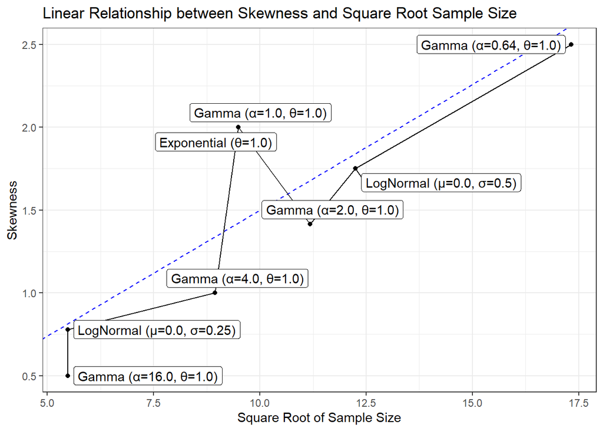

```r
model <- lm(Skewness ~ sqrt(`Sample Size`), df)
df |>
  ggplot(aes(x = sqrt(`Sample Size`), y = Skewness, label = Distribution)) +
  geom_abline(slope = coef(model)[2], intercept = coef(model)[1], color = "blue", linetype = "dashed") +
  geom_line() +
  geom_point() +
  geom_label_repel() +
  labs(
    title = "Linear Relationship between Skewness and Square Root Sample Size",
    x = "Square Root of Sample Size",
    y = "Skewness"
  ) +
  theme_bw()
```

```r
summary(model)
```

```
Call:
lm(formula = Skewness ~ sqrt(`Sample Size`), data = df)

Residuals:
    Min      1Q  Median      3Q     Max
-0.3397 -0.2771 -0.1017  0.1184  0.5779

Coefficients:
                    Estimate Std. Error t value Pr(>|t|)
(Intercept)         -0.01901    0.42072  -0.045  0.96542
sqrt(`Sample Size`)  0.15190    0.03978   3.819  0.00877 **
---
Signif. codes:  0 '***' 0.001 '**' 0.01 '*' 0.05 '.' 0.1 ' ' 1

Residual standard error: 0.4028 on 6 degrees of freedom
Multiple R-squared:  0.7085,    Adjusted R-squared:  0.6599
F-statistic: 14.58 on 1 and 6 DF,  p-value: 0.008772
```

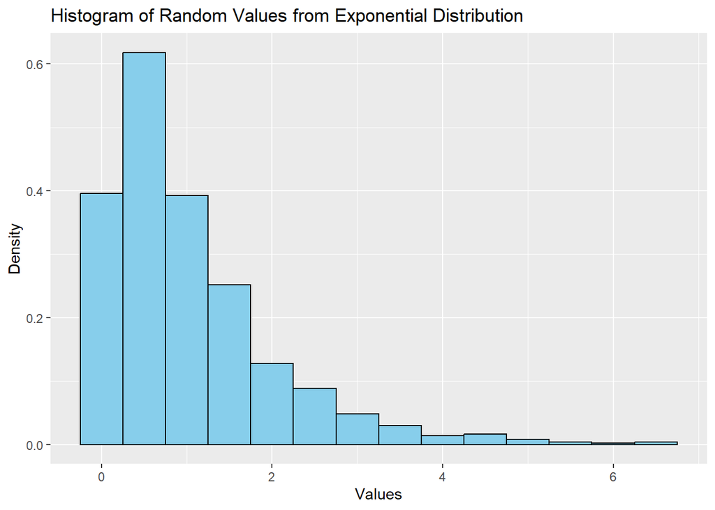

```r
set.seed(0)

# Generate random values from a normal distribution
data <- rexp(1000)

df <- data.frame(value = data)

# Create a histogram using ggplot2
ggplot(data = df, aes(x = value)) +
  geom_histogram(binwidth = 0.5, fill = "skyblue", color = "black", aes(y = after_stat(density))) +
  labs(
    title = "Histogram of Random Values from Exponential Distribution",
    x = "Values",
    y = "Density"
  )
```